# Evaluation of sliding window correlation performance for characterizing dynamic functional connectivity and brain states - ScienceDirect

- [View **PDF**](https://www.sciencedirect.com/science/article/pii/S1053811916001920/pdfft?md5=5bb02b4f4ed9f5e8a5e4c2a530afd307&pid=1-s2.0-S1053811916001920-main.pdf)

## Figures (12)

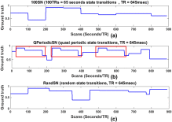

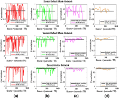

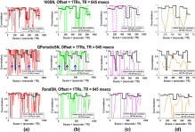

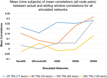

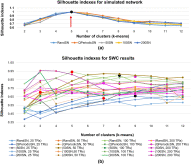

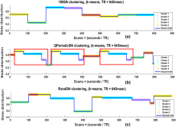

## Tables (2)

1. Table 1
2. Table 2

## [NeuroImage](https://www.sciencedirect.com/science/journal/10538119)

[Volume 133](https://www.sciencedirect.com/science/journal/10538119/133/supp/C), June 2016, Pages 111-128

# Evaluation of sliding window correlation performance for characterizing dynamic functional connectivity and brain states

[SadiaShakil<sup>a</sup><sup>1</sup>](https://www.sciencedirect.com/science/article/pii/S1053811916001920#!)[Chin-HuiLee<sup>a</sup><sup>1</sup>](https://www.sciencedirect.com/science/article/pii/S1053811916001920#!)[Shella DawnKeilholz<sup>b</sup><sup>c</sup><sup>2</sup>](https://www.sciencedirect.com/science/article/pii/S1053811916001920#!)

https://doi.org/10.1016/j.neuroimage.2016.02.074[Get rights and content](https://s100.copyright.com/AppDispatchServlet?publisherName=ELS&contentID=S1053811916001920&orderBeanReset=true)

## Highlights

**•**

We evaluate sliding window correlation as a dynamic network analysis method.

**•**

We evaluate k-means for state identification of the results.

**•**

Use of simulated networks provides ground truth for performance evaluation.

**•**

Window length, offset, and filtering significantly influence the results

## Abstract

A promising recent development in the study of brain function is the dynamic analysis of resting-state functional MRI scans, which can enhance understanding of normal cognition and alterations that result from brain disorders. One widely used method of capturing the dynamics of [functional connectivity](https://www.sciencedirect.com/topics/medicine-and-dentistry/functional-connectivity) is sliding window correlation (SWC). However, in the absence of a “gold standard” for comparison, evaluating the performance of the SWC in typical resting-state data is challenging. This study uses simulated networks (SNs) with known transitions to examine the effects of parameters such as window length, window offset, window type, noise, filtering, and sampling rate on the SWC performance. The SWC time course was calculated for all node pairs of each SN and then clustered using the k-means algorithm to determine how resulting *brain states* match known configurations and transitions in the SNs. The outcomes show that the detection of state transitions and durations in the SWC is most strongly influenced by the window length and offset, followed by noise and filtering parameters. The effect of the image sampling rate was relatively insignificant. Tapered windows provide less sensitivity to state transitions than rectangular windows, which could be the result of the sharp transitions in the SNs. Overall, the SWC gave poor estimates of correlation for each brain state. Clustering based on the SWC time course did not reliably reflect the underlying state transitions unless the window length was comparable to the state duration, highlighting the need for new adaptive window analysis techniques.

## Abbreviations

rsfMRI

resting-state functional magnetic resonance imaging

FC

functional connectivity

SWC

sliding window correlation

SN

simulated network

GT

ground truth

## Keywords

Resting-state functional MRI

Functional connectivity

Sliding window correlation

Network dynamics

k-Means

States

## Introduction

Resting-state functional MRI (rsfMRI) has had much success as a tool for the study of normal and disordered brain function (Rombouts et al., 2005, Sorg et al., 2007, Zang et al., 2007; Xia et al., 2013). Initially, rsfMRI analysis assumed networks in the resting-brain were stationary over the whole scan length (typically ranging from six to ten minutes), but more recently methods that examine the network connectivity as a function of time have been applied. Several studies have reported that the connectivity of these networks changes over the course of the scan (within a few seconds) and reveal a number of [functional connectivity](https://www.sciencedirect.com/topics/medicine-and-dentistry/functional-connectivity) (FC) states in the brain, which can be sensitive to changes related to [neurological disorders](https://www.sciencedirect.com/topics/medicine-and-dentistry/neurologic-disease) (Sakoğlu et al., 2010, Leonardi et al., 2013a, Leonardi et al., 2013b; Damaraju et al., 2014, Li et al., 2014, Ou et al., 2015). These dynamics are also linked to changes in human behavior (Kucyi et al., 2013, Thompson et al., 2013a, Thompson et al., 2013b; Jia et al., 2014, Sadaghiani et al., 2015).

Sliding window correlation (SWC) is the simplest and most commonly used method for dynamic FC analysis and most of the dynamic FC studies use it at some point (Schulz and Huston, 2002; Chang and Glover, 2010; Kiviniemi et al., 2011, Handwerker et al., 2012, Chang et al., 2013, Hutchison et al., 2013a, Hutchison et al., 2013b; Keilholz et al., 2013, Thompson et al., 2013a, Thompson et al., 2013b; Wilson et al., 2015). It should be noted that in this study dynamic FC refers to the dynamics of [resting-state networks](https://www.sciencedirect.com/topics/medicine-and-dentistry/resting-state-network) only and not the dynamics because of any environmental input or task. In the SWC, a temporal window of a certain size and shape is selected, and the correlation coefficient between two signals of interest within that window is computed. Afterwards the window is shifted (slided) by some offset, and the process is repeated for the entire scan length. Despite the popularity of the SWC, results are strongly dependent on window length (Sakoğlu et al., 2010, Hutchison et al., 2013a, Hutchison et al., 2013b; Keilholz et al., 2013, Wilson et al., 2015) and the ideal values for this and other parameters for the dynamic FC analysis remain unknown. A nice but simplified examination of the relationship between the minimum window length and the frequency components of the signals has been presented (Leonardi and Van De Ville, 2015). Another study used windows of different sizes on resting state and sleep data and reported that short epochs can be used effectively for dynamic FC analysis (Wilson et al., 2015). However, no study has convincingly identified the best window length for dynamic FC analysis. Furthermore, since these brain networks change states at random times, using the same window over the entire rsfMRI scan may not be the optimum method to capture the true dynamic configurations of these networks. The effect of window length, offset, and other parameters has not been systematically examined in realistic data, and a recent study that looked at the effect of window length on the correlation between the BOLD signal and simultaneously-acquired [local field potentials](https://www.sciencedirect.com/topics/medicine-and-dentistry/local-field-potential) found that the optimal window length is somewhat ambiguous (Thompson et al., 2013a, Thompson et al., 2013b).

After the SWC is performed pairwise for the brain areas of interest, clustering is often used to find the number of ‘states’ that occur over the length of the scan, and the times at which transitions occur (Hutchison et al., 2013a, Hutchison et al., 2013b; Allen et al., 2014, Damaraju et al., 2014, Shakil et al., 2014). The most commonly used method for clustering SWC results is based on the k-means algorithm (Hutchison et al., 2013a, Hutchison et al., 2013b; Allen et al., 2014, Damaraju et al., 2014, Shakil et al., 2014). The accuracy of the clustering depends on the clustering algorithm and the ability of the SWC to resolve transitions of interest, emphasizing the need to evaluate the SWC parameters.

The biggest obstacle in identifying the best approach to the SWC and clustering for dynamic FC analysis is that there is no ‘ground truth (GT)’ in standard rsfMRI data, since the actual network dynamics, number of states, and state transitions are all unknown. This study circumvents this problem by using simulated networks (SNs) with known transition points created from real rsfMRI data. We evaluate the SWC algorithm and the effects of window size, window shift, window type, noise, filtering, and sampling or repetition time (TR) on the SWC results, and on the correct identification of state transitions and durations obtained from these results using k-means clustering. As expected, window size and offset had a substantial impact on the accuracy of the results, followed by the impact of noise and filtering, while TR had a very small impact. Tapered windows resulted in poorer state identification than rectangular windows due to the abrupt sharp state transitions present in the SNs. These findings motivate further work on methods that can dynamically adapt the length of the window during the analysis or the formulation of an algorithm which can more accurately detect the state transition points.

## Material and methods

### Data and preprocessing

We used rsfMRI scans of nine healthy human subjects (four females, ages: 21–57 years, downloaded from Nathan Klein Institute's Enhanced Rockland dataset of 1000 Functional Conectome Project (http://www.nitrc.org/projects/fcon_1000/). The scans were done on SIEMENS MAGNETOM TrioTim syngo MR B17 scanner. The scanning parameters were: TR = 645 ms, voxel size = 3 mm isotropic, duration = 10 min, TE = 30 ms, slices = 40, multi-band accel, factor = 4, and time points = 900. Each scan contained 900 volumes and the initial 10 volumes of each scan were discarded to compensate for transient scanner instability. All preprocessing was done in [statistical parametric mapping](https://www.sciencedirect.com/topics/neuroscience/statistical-parametric-mapping) (SPM 12, http://www.fil.ion.ucl.ac.uk/spm/). Preprocessing included motion correction, coregistration of the functional images with the anatomical image, segmentation, normalization, and smoothing. Default parameter values from SPM12 were used during preprocessing but smoothing was done using a Gaussian kernel of size 8 and for normalization a voxel size of 3 × 3 × 3 was chosen. The images were coregistered to the AAL atlas (Tzourio-Mazoyer et al., 2002) using nearest neighbor interpolation without any warping.

After preprocessing, five functional networks (dorsal DMN, ventral DMN, anterior-salience, visuospatial, and sensorimotor) were extracted using the masks from the Stanford FIND (http://findlab.stanford.edu/home.html) lab (Shirer et al., 2012) for all subjects.

### Region-of-interest (ROI) time series

For each subject, seven, non-overlapping, three-dimensional, regions-of-interest (ROIs) consisting of 3 × 3 × 3 voxels were chosen from each of the abovementioned five networks (dorsal DMN, ventral DMN, anterior-salience, visuospatial, and sensorimotor). The anatomical location of the ROIs in the five networks (taken from Supplementary data of Shirer et al. (2012)) is given in Supplementary Fig. 1. Maps of the five functional networks (taken from Supplementary data of Shirer et al. (2012)) along with the locations of the ROIs selected for the current study (arrows) are given in Supplementary Fig. 2. Each ROI time series was formed by extracting the intensities of the voxels in the ROI and then computing their mean at each time point. In order to observe the dependency of the analysis on the location of ROIs, we later performed the analysis on a second, entirely different sets of ROIs (shown in Supplementary Fig. 3). These ROIs were used to create simulated networks (SNs) as described in the next section. The averaged time series of each ROI was extracted and bandpass filtered (0.016–0.08 Hz, order 20 FIR) before the formation of the SNs. As expected, the ROIs that came from the same network were highly correlated, which was confirmed by computing the pairwise stationary correlations (Supplementary Fig. 4).

### Sliding window correlation of actual resting-state networks

The main goal of this study was to analyze the performance of the SWC with variable parameters using SNs with known timing formed from real rsfMRI data. However, before starting this analysis we computed the pairwise SWC of the time series of the five actual networks (dorsal DMN, ventral DMN, anterior-salience, visuospatial, and sensorimotor) using the same window sizes as the ones used for the SNs (discussed in detail in the Simulated networks and sliding window correlation section). The purpose was to compare the SWC of the actual data with the results of previous studies (Hutchison et al., 2013a, Hutchison et al., 2013b; Keilholz et al., 2013, Wilson et al., 2015), and to determine how the abrupt intensity changes (outliers) introduced in our SNs due to state transitions (explained in the Simulated networks and sliding window correlation section) might influence results of the SWC.

### Simulated networks and sliding window correlation

To form a SN, seven ROIs from one of the abovementioned rsfMRI networks were used. A portion of the time courses for these ROIs was taken and used as the time courses for the seven nodes of the SN until the first state transition point t<sub>1</sub>. At t<sub>1</sub>, a portion of the time courses from the seven ROIs of a different network was added to the SN to create a new state lasting from t<sub>1</sub> to t<sub>2</sub>. This process was repeated until the desired length of 890 time points was obtained. For example, if we chose the nodes from ventral DMN from t<sub>1</sub> to t<sub>2</sub>, then the nodes from t<sub>2</sub> to t<sub>3</sub> were from another network e.g. sensorimotor network of the same subject, and this process continued till we reached the last interval from t<sub>n</sub> <sub>− 1</sub> to t<sub>n</sub>. Formation of the SNs in such a manner incorporated real rsfMRI data but gave us control over the time at which the SNs changed states (switched from one resting-state functional network to another) since we chose the transition times t<sub>1</sub> to t<sub>n</sub>. It should be noted here that our SNs were formed from five [resting-state networks](https://www.sciencedirect.com/topics/medicine-and-dentistry/resting-state-network) but some of them had more than five transitions which means the data from the same resting-state network would be taken more than once in formation of these SNs. However, apart from one SN (QPeriodicSN explained later in this section) there is no repetition of data. For example, if the data from ventral DMN is taken for the durations t<sub>x − 1</sub> to t<sub>x</sub> and t<sub>y − 1</sub> to t<sub>y</sub> (x and y are integers) for a SN then it would be from two entirely different non-overlapping intervals of the ventral DMN. This step insured that no two parts of a SN has exactly the same correlation values between the node pairs (except for QPeriodicSN).

The configuration of a SN between any two consecutive transition points is referred to as one ‘state’ of that SN since it was formed by data from one FC network (state) of original resting-state scans. All the states of a SN (except QPeriodicSN) have different correlation values between the node pairs but more than one of these states may be from the same resting-state network. By changing the transition points we were able to form five different SNs. Three of these SNs were formed with state transitions at equal intervals (state transition at every 50 TRs for 50SN, at every 100 TRs for 100SN, and at every 200 TRs for 200SN, TR = 645 ms). Real resting-state networks are unlikely to change configurations at equal intervals but the analysis with these SNs allowed us to explore the best choice of the sliding window parameters for the ideal case of regularly changing networks. However, we also formed two SNs where the state transitions occurred at random intervals to evaluate the performance of the SWC in more realistic scenario. In the first randomly changing network, we used quasi periodicity by repeating three states at random points during the formation of the SN (QPeriodicSN). The second randomly changing network (RandSN) had completely random state change points with state durations from 20 TRs (≈ 13 s) to 130 TRs (≈ 84 s).The formation of these five SNs allowed us to examine the sensitivity of the SWC to regular states of different lengths, and randomly changing states with or without quasi periodicity. The state durations for the SNs ranged from ≈ 13 s to ≈ 129 s, while the window lengths used were ≈ 17, 33, 65 and 129 s (25 TRs, 50 TRs, 100 TRs, and 200 TRs, TR = 645 ms). All of these window lengths were within the sizes commonly reported in the literature that vary from 8 to 240 s (Chang and Glover, 2010; Kiviniemi et al., 2011, Handwerker et al., 2012, Chang et al., 2013, Keilholz et al., 2013, Thompson et al., 2013a, Thompson et al., 2013b; Kucyi and Davis, 2014; Wilson et al., 2015).

In their papers (Leonardi and Van De Ville, 2015; Shakil et al., 2015), explored the relationship of frequency components in the correlating signals and window length. (Leonardi and Van De Ville, 2015) established the mathematical relationship between the window length and the minimum frequency (f<sub>min</sub>) of the correlating time series. By using simple [sinusoids](https://www.sciencedirect.com/topics/medicine-and-dentistry/sinusoid) (Leonardi and Van De Ville, 2015) reported that the minimum window length should at least be equal to 1/f<sub>min</sub> in order to avoid spurious fluctuations arising due to the SWC algorithm itself. Using the same guidelines (Shakil et al., 2015) explored the effect of two frequencies on the SWC results. Since the frequency components of the signals may influence the results of the SWC, we plotted log<sub>10</sub> (power spectrum) vs. log<sub>10</sub> (frequency) of the actual (ROI) and SN time series in Supplementary Figs. 5(a) and (b) respectively. The frequency characteristics are similar, however, due to abrupt transitions in the SNs, the power spectrum changes in the SNs are less smooth. It should be mentioned here that there is no one to one correspondence between the plots in (a) and (b). The plots in (a) are for original rsfMRI networks, while those in (b) are for SNs that were formed by combination of time series in (a).

Overall five SNs were formed from each subject's data: Three with equal duration states and two with randomly changing states. The equal duration SNs had 18 (50SN), 9 (100SN), and 5 (200SN) distinct states of FC. QPeriodicSN had a total of 15 FC states, of which three were repeated at random time points, while RandSN had 10 distinct FC states changing at random times. We computed SWC for all of these SNs for different window lengths and other parameters to determine the best combination of parameters for SWC as a dynamic FC analysis method. Detailed results from the SNs created from one randomly selected subject's data along with the mean results of all SNs created from all nine subjects are reported in this study.

### Ground truth

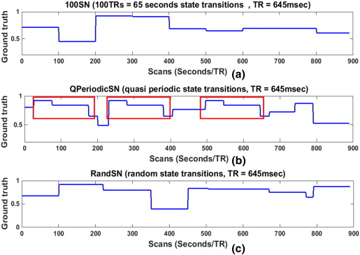

Fig. 1. Ground truths (GTs) for (a) 100SN, (b) QPeriodicSN, and (c) RandSN. 100SN has state transitions at every 100 TRs (65 s), QPeriodicSN has quasi periodic states (red rectangles) repeated at random times, and RandSN has all the states transitions at random times. Each SN has seven nodes and ground truth for any SN is the mean of actual correlations of all of its node pairs.

### Inter-subject variability of the SWC

We computed the actual correlations of all SN node pairs in all subjects and their mean was taken as GTs (Fig. 1 and Supplementary Fig. 6). In order to observe the deviation of the SWC results from actual correlations, we computed the correlations of the actual correlations and SWCs for all node pairs for all the windows in each subject. We then calculated the means of these correlations for each subject (over all node pairs) to observe the inter-subject variability of these correlations. Afterwards, we computed the overall mean for all the nine subjects to show the overall trend of correlation changes for each window.

### Sliding window correlation parameters

Six parameters were varied to explore their influence on the sensitivity of the SWC and subsequent clustering. For all parameter values, the SWC was calculated pairwise for all nodes of each SN.

**a)**

*Window length*: Gonzalez-Castillo et al. (2014) reported that resting-state networks exhibit long-term stability and that the similarity of within-subject whole brain connectivity is a function of window duration. In various dynamic FC studies based on the SWC, the window length ranges from 8 to 240 s (Chang and Glover, 2010; Kiviniemi et al., 2011, Keilholz et al., 2013, Allen et al., 2014). We examined windows of 25, 50, 100, and 200 TRs (≈ 17, 33, 65 and 129 s). All the window sizes were within the limits reported in the literature (Chang and Glover, 2010; Kiviniemi et al., 2011, Keilholz et al., 2013, Allen et al., 2014, Kucyi and Davis, 2014; Wilson et al., 2015).

**b)**

*[Signal-to-noise ratio](https://www.sciencedirect.com/topics/medicine-and-dentistry/signal-to-noise-ratio)* *(SNR)*: The signal-to-noise ratio (SNR) of rsfMRI data depends on a number of factors and can include structured noise due to motion or physiological cycles (Kruger and Glover, 2001; Greve et al., 2013, Bright and Murphy, 2015). In order to explicitly examine the influence of random noise on the identification of states using the SWC, additive white Gaussian noise (AWGN) (using awgn() in Matlab) was added to the time series of each SN at levels of 10 dB and 20 dB. We also examined the effect of reduced SNR by selecting random single voxels from random slices as nodes of our SNs instead of 3 × 3 × 3 voxels ROIs.

**c)**

*Window offset*: Typical window offsets used in previous studies range from 1 to 20 s (which covers the range from a single TR step to 50% of the window length) (Chang et al., 2013, Keilholz et al., 2013, Kucyi and Davis, 2014; Shakil et al., 2014). The majority of this study uses a window offset of one TR (645 ms), but the effects of offsets equal to one-fourth or one-half of the window lengths were also explored.

**d)**

*Window type*: Typically rectangular windows are used for the SWC analysis (Chang et al., 2013, Keilholz et al., 2013, Kucyi and Davis, 2014; Shakil et al., 2014). The majority of the work in this study also utilized a rectangular window but the impact of using tapered (Hamming, Hanning) windows were also examined.

**e)**

*Filtering*: Typical rsfMRI studies bandpass filter (0.01–0.08 Hz or 0.01–0.1 Hz) the time series in order to reduce the effects of noise. Two recent studies (Leonardi and Van De Ville, 2015; Shakil et al., 2015) have shown that the frequency components of the signal and the window size interact to impact final SWC results. Both the studies showed that the spurious correlations of the SWC results are reduced when the size of the window is greater than 1/f<sub>min</sub> (f<sub>min</sub> = minimum frequency). Since both of these studies reported a relationship between the minimum frequency of the correlating signals and the shortest recommended window length, we explored this relationship by varying the minimum frequency content of the rsfMRI signal. For this purpose we used highpass filtered (> 0.016 Hz, > 0.05 Hz and > 0.08 Hz) time series to form SNs, corresponding to minimum window lengths of 62.5, 20, and 12.5 s respectively.

**f)**

*Repetition time (TR)*: Most simulations used SNs formed from scans acquired with a TR of 645 ms, but analysis was also performed on scans with 1400 ms TR to determine how a lower sampling rate influences SWC results and their state distributions.

### Clustering

One of the major goals of this study was to determine how well the clustering based on the SWC performs at identifying network state durations and transitions. In previous dynamic FC studies, k-means clustering was used on SWC results to extract states of FC (Leonardi et al., 2013a, Leonardi et al., 2013b; Allen et al., 2014, Damaraju et al., 2014, Shakil et al., 2014). We also applied k-means clustering to the SWC results to determine whether state transitions and durations were identified correctly. For this purpose, the SWC results were grouped into clusters called “Cstates” and the results were examined to determine how well the Cstates coincided with the known state transitions and durations shown in the GTs (Fig. 1 and Supplementary Fig. 6). In order to evaluate the performance of k-means clustering alone for state identification, we clustered the raw time courses for the seven nodes of each SN in addition to clustering the SWC results. Silhouette criteria was used to determine the best number of clusters for each data set. The number of clusters was varied from two to twelve and the overall mean of silhouettes was computed (Rousseeuw, 1987). We selected the number of clusters (raw SNs) and Cstates (SWC results) for each case when this mean became constant or started to decrease.

In general, the number of Cstates for all windows and all SNs was less than or equal to the actual number of states in the SN (10 for RandSN, 15 for QPeriodicSN, 18 for 50SN, 9 for 100SN, and 5 for 200SN), resulting in the assignment of more than one state to the same Cstate. To determine the similarity of states assigned to the same Cstate, the Euclidean distance between them was computed.

## Results

### Sliding window correlation of actual ROI time series

We computed pairwise SWC of the actual ROI time series of the five functional networks (dorsal DMN, ventral DMN, anterior-salience, visuospatial, and sensorimotor) for all windows. Fig. 2 shows the results of the pairwise SWC along with the stationary correlations (black horizontal lines). The node pairs are selected at random from three of the five networks (dorsal DMN, ventral DMN, and sensorimotor network). It can be observed that for all cases the SWC varies around the actual correlation but the extent of variability is largest for the smallest window (25 TRs, red in (a)) and decreases as the window size increases towards right. The same plots (overlaid on each other) are shown for three other pairs of randomly selected nodes in Supplementary Fig. 7. All the plots of these figures show a similar trend and are in accordance with the results reported in Hutchison et al., 2013a, Hutchison et al., 2013b, Keilholz et al. (2013), and Wilson et al. (2015).

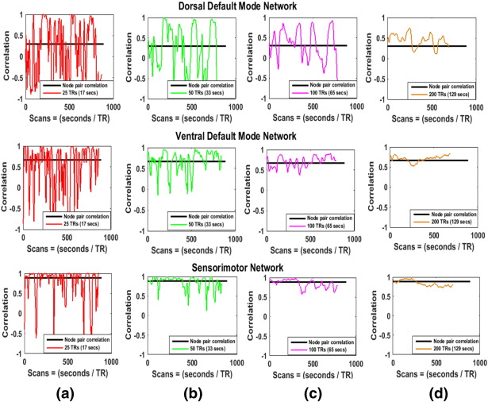

Fig. 2. Stationary and sliding window correlations of three node pairs (selected at random) from three different real [resting-state networks](https://www.sciencedirect.com/topics/medicine-and-dentistry/resting-state-network). Stationary correlations of the node pairs are shown by black horizontal lines. The size of the window increases from left to right. The SWC fluctuates around the stationary correlation and these fluctuations are largest for smallest window in (a) and decrease as the window size increases towards the right.